# HR- Employee Attrition and Analysis

Table of Contents

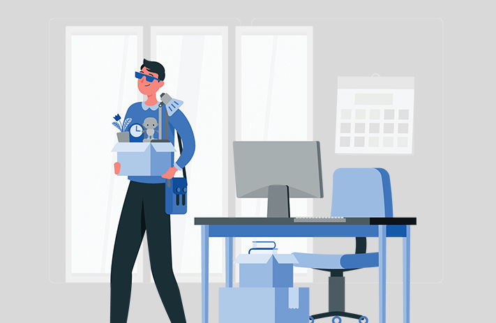

# **Introduction**

Attrition refers to employees leaving an organization without the organization being able to immediately fill their vacancies. High rates of employee attrition often occur when key factors, such as inadequate compensation, poor work-life balance, ineffective management, lack of career advancement opportunities, and poor working conditions, are left unaddressed.

Understanding *who* leaves and *why* is crucial for improving workplace policies, reducing turnover, and minimizing the negative impact on productivity, culture, and financial performance. High attrition can lead to increased recruitment and training costs, loss of institutional knowledge, and burnout among remaining staff. Luckily, there are solutions. By effectively leveraging data-driven insights from employee surveys, exit interviews, and feedback, organizations/companies can identify root causes to employee attrition and implement targeted strategies to improve retention and create a healthier work environment.

## **Project Scope**

This analysis covers **6** key areas:

### 1. **Data Cleaning in SQL**

Using SQL to inspect, clean, and prepare the dataset for analysis.

### 2. **Exploratory Data Analysis in SQL & R**

- Perform initial EDA in SQL with the string and binary variables
- Create visualizations in R to uncover relationships in the data with the numeric, binary, and string variables

### 3. **Logistic Regression in R**

Using regression to determine which factors contribute to employee attrition.

### 4. **Machine Learning Model**

- Splitting the dataset
- Training a predictive model

### 5. **Model Evaluation**

Using accuracy metrics like **F1-score**, **Precision**, **Recall**, and **ROC-AUC** to assess model performance.

### 6. **Interpretation & Real-World Implications**

Analyzing model results and discussing practical applications in HR.

## **Data Source**

**🔗 to Code**: [IBM HR Analytics Employee Attrition and Performance-Kaggle](https://www.kaggle.com/datasets/pavansubhasht/ibm-hr-analytics-attrition-dataset/data)

This is a fictional data set created by IBM data scientists. It includes the data of nearly 1500 employees and 35 variables. The dataset contains information on employee demographics, income, job satisfaction, job information, and whether or not the employee attrited.

**Click to View Dataset Variables and Definitions**

| # | Variable | Definition |
| --- | --- | --- |
| 1 | Age | Age of employee |
| 2 | Gender | Employee’s gender (male/female) |
| 3 | Attrition | Whether employee left company (Yes/No) |
| 4 | BusinessTravel | Frequency of travel (Rarely, Frequently, etc.) |
| 5 | DailyRate | Daily salary rate (USD) |
| 6 | Department | Department of employee (Sales, R&D, etc.) |
| 7 | DistanceFromHome | Distance from home to work (miles) |
| 8 | Education | Level of education achieved by employee (1.Below College, 2.College, etc.) |
| 9 | EducationField | Employee’s field of study |
| 10 | EmployeeCount | N/A |
| 11 | EmployeeNumber | Unique identifier for each employee |
| 12 | EnvironmentSatisfaction | Employee satisfaction with working environment (1-4) |
| 13 | HourlyRate | Hourly salary rate (USD) |
| 14 | JobInvolvement | Level of involvement required for employee’s job (1-4) |
| 15 | JobLevel | Employee’s level of work (1-5) |
| 16 | JobRole | Employee’s role in the organization (Sales exec., Lab Tech., etc.) |
| 17 | JobSatisfaction | Satisfaction rating of the job (1-4) |
| 18 | Marital Status | Employee’s marital status (S, M, D) |
| 19 | MonthlyIncome | Employee’s monthly salary ($) |
| 20 | Monthly Rate | Monthly salary rate (USD) |
| 21 | NumCompaniesWorked | # of companies the employee worked for |
| 22 | Over 18 | Whether or not the employee is 18 yrs old |
| 23 | OverTime | Whether or not the employee works overtime (yes/no) |
| 24 | PercentSalaryHike | Salary increase rate |
| 25 | PerformanceRating | Performance rating of employee (1-4) |
| 26 | RelationshipSatisfaction | Employee’s satisfaction with personal relationships (1-4) |
| 27 | StandardHours | Standard working hours for employees |
| 28 | StockOptionLevel | Employee’s stock option level |
| 29 | TotalWorkingYears | Total # of years the employee has worked |
| 30 | TrainingTimesLastYear | # of trainings the employee has taken |
| 31 | WorkLifeBalance | Employee’s perception of their work-life balance (1-4) |
| 32 | YearsAtCompany | # of years employee has been with current company |
| 33 | YearsInCurrentRole | # of years employee has been in current role |
| 34 | YearsSinceLastPromoted | # of years since last promotion |
| 35 | YearsWithCurrManager | # of years with current manager |

**Disclosure**: This data is intended for research purposes and data practice. Models designed from this data are not designed to predict future attrition X number of months from now. Models are trained on a portion of the employees and test it on the unseen employees. Therefore, this model will simply be able to distinguish between employees who leave and who stay and what factors make them different.

# **SQL CODE**

### **How to connect to your SQL database in R**

```r
# 1.) Install & load necessary packages
library(RPostgres)  #to connect to SQL code
library(DBI)        #connecting to SQL database

# 2.) Enter database info
connection <- dbConnect(Postgres(),
                 dbname = "Name_Of_Your_Database",
                 host = "yourHost",
                 port = "####",
                 user = "insert_user",
                 password = "**********")
```

## 1. Data Cleaning

### **Step 1**: Load dataset into new table

Additionally, I changed the name of variables by just putting underscores. Just for my own satisfaction. Over18 was removed before querying.

```sql
Drop Table if Exists hr_attrition_transformed;
```

```sql
CREATE TABLE hr_attrition_transformed AS  --the new table for analysis in R and EDA.
Select *
From hr_attrition;
--34 variables
```

### **Step 2**: Check data for consistency

We could check for every single variable, and usually its right to do so, but for the sake of time we will select a few of the variables with text.

```sql
Select Distinct(business_travel)
From hr_attrition_transformed; --3 levels. No typos.
```

3 records

| business_travel |
| --- |
| Non-Travel |
| Travel_Frequently |
| Travel_Rarely |

```sql
Select Distinct(gender)
From hr_attrition_transformed; -- No typos
```

2 records

| gender |
| --- |
| Female |
| Male |

```sql
Select Distinct(department)
From hr_attrition_transformed; --No typos
```

3 records

| department |
| --- |
| Human Resources |
| Research & Development |
| Sales |

### **Step 3**: Identify count of *NULL* in ‘attrition’ and ‘employee_number’

```sql
Select COUNT(*) as null_count
From hr_attrition_transformed
Where attrition is NULL OR employee_number is NULL;
```

1 records

| null_count |
| --- |
| 0 |

### **Step 4**: Remove unnecessary columns

```sql
Alter Table hr_attrition_transformed
Drop Column daily_rate, --not useful; may vary
Drop Column hourly_rate, --not useful; may vary
Drop Column monthly_rate, --not useful; may vary
Drop Column distance_from_home, --range is 1-29 miles
Drop Column standard_hours, --nonsensical; same for all employees
Drop Column employee_count; --nonsensical; every value is 1
```

### **Step 5**: Converting ‘attrition’, ‘gender’, and ‘overtime’ to 0,1 for model preference

```sql
Select
    Case When attrition = 'Yes' Then 1 Else 0 End, -- yes = 1, no = 0
    Case When gender = 'Male' Then 1 Else 0 End,
    Case When overtime = 'Yes' Then 1 Else 0 End
From hr_attrition_transformed;
```

```sql
Update hr_attrition_transformed
Set attrition = Case When attrition = 'Yes' Then 1 Else 0 End,
    gender = Case When gender = 'Male' Then 1 Else 0 End,
    overtime = Case When overtime = 'Yes' Then 1 Else 0 End;
```

```sql
Select attrition, gender, overtime
From hr_attrition_transformed
Limit 3;
```

3 records

| attrition | gender | overtime |
| --- | --- | --- |
| 0 | 1 | 0 |
| 0 | 1 | 0 |
| 0 | 0 | 0 |

### **Step 6**: One-Hot encoding ‘marital_status’

```sql
Select Distinct marital_status --checking levels of a variable
From hr_attrition_transformed;
```

3 records

| marital_status |
| --- |
| Single |
| Married |
| Divorced |

```sql
Alter Table hr_attrition_transformed
ADD is_single INT,
ADD is_married INT,
ADD is_divorced INT;
```

```sql
Update hr_attrition_transformed
Set is_single = Case When marital_status = 'Single' Then 1 Else 0 End,
    is_married = Case When marital_status = 'Married' Then 1 Else 0 End,
    is_divorced = Case When marital_status = 'Divorced' Then 1 Else 0 End;
```

```sql
Select employee_number, marital_status, is_single, is_married, is_divorced
From hr_attrition_transformed
Limit 3;
```

3 records

| employee_number | marital_status | is_single | is_married | is_divorced |
| --- | --- | --- | --- | --- |
| 520 | Divorced | 0 | 0 | 1 |
| 997 | Divorced | 0 | 0 | 1 |
| 1191 | Divorced | 0 | 0 | 1 |

### **Step 7**: Creating ‘annual_income’ variable to condense income info

```sql
Alter Table hr_attrition_transformed
Add Column annual_income INT;
```

```sql
Update hr_attrition_transformed
Set annual_income = monthly_income * 12;
```

```sql
Select annual_income
From hr_attrition_transformed
Limit 3;
```

3 records

| annual_income |
| --- |
| 172032 |
| 208788 |
| 239316 |

## 2. EDA in SQL

### Attrition Count

```sql
Select attrition,
COUNT(*) AS count_attrition
From hr_attrition_transformed
Group By attrition
Order By attrition;

-- NOTE: this is an imbalanced data set. Important for our model.
```

2 records

| attrition | count_attrition |
| --- | --- |
| 0 | 1233 |
| 1 | 237 |

### Annual Income & Attrition

```sql
Select attrition,
        MIN(annual_income) AS min_income,
        MAX(annual_income) AS max_income,
        ROUND(AVG(annual_income), 2) AS avg_income
From hr_attrition_transformed
Group By attrition
Order By attrition;

    --NOTE: those leaving earn about 25K less. Range looks similar,
    -- but distribution might be different. We can easier see the median in R.
```

2 records

| attrition | min_income | max_income | avg_income |
| --- | --- | --- | --- |
| 0 | 12612 | 239988 | 81992.88 |
| 1 | 12108 | 238308 | 57445.11 |